# R Notebook

Important packages:

```r
setwd("Dataset")
Dataset <- read.csv("data.csv")
Preprocessed_dataset <-  read.csv("preprocessed_dataset.csv")
if(!require(ggplot2)){
install.packages("ggplot2")}
library(ggplot2)
if(!require(dplyr)){
install.packages("dplyr")}
library(dplyr)
if(!require(dplyr)){
install.packages("dplyr")}
library(dplyr)
if(!require(ltm)){
install.packages("ltm")}
library(ltm)
if (!require(cluster, quietly = TRUE)) {
  install.packages("cluster")
}
if (!require(factoextra, quietly = TRUE)) {
  install.packages("factoextra")
}
```

# IT326 Project

_________________________________________________________________________________________________________

## The Goal

Our primary objective of this analysis is to classify whatever a student will go to college or not using the classification methods and to identify the main factors and reasons why students are less likely to pursue higher education indicated by “will_go_to_college” being ‘False’. By leveraging the provided dataset with attributes such as school type, school accreditation, gender, interest in college, residence, we aim to discover the most influential variables and their relationships with the decision not to attend college.

## The Source

Kaggle.com

## URL :

https://www.kaggle.com/datasets/saddamazyazy/go-to-college-dataset

## General information

- Number of attributes : 11
- Number of rows (objects) : 1000
- The class label: The class label in our project is the attribute “will_go_to_college”. This attribute is binary, meaning that it can take on two values: True for yes or False for no. The value of this attribute will be the target variable that we are trying to predict during our project.

| Attribute | Description | Type | Possible values |
| --- | --- | --- | --- |
| type_school | The type of school the student attends | Binary | Academic / Vocational |
| school_accreditation | The quality if school | Binary | A / B (A is better than B) |
| gender | The student’s gender | Binary | Male / Female |
| interest | The student’s interest in going to college | Nominal | Very interested /Interested / Less Interested / Not Interested /Uncertain |
| residence | The student’s residence | Binary | Urban / Rural |
| parent_age | The age of the student’s parents | Numeric | 40 - 65 |
| parent_salary | The monthly salary of the student’s parents in IDR/Rupiah. [1Rupiah = 0.00024SAR] | Numeric | 1000K - 10M |
| house_area | The size of the student’s house in meter square | Numeric | 20 - 120 |
| average_grades | The student’s average grades in school. | Numeric | 75 - 98 |
| parent_was_in_college | Whether the student’s parents attended college. | Binary | True - False |
| will_go_to_college | Whether the student plans to go to college. | Binary | True - False |

## Sample of our data

```r
head(Dataset)
```

|  | type_school | school_accreditation | gender | interest | residence | parent_age | parent_salary | house_area | average_grades | parent_was_in_college | will_go_to_college |
| --- | --- | --- | --- | --- | --- | --- | --- | --- | --- | --- | --- |
| 1 | Academic | A | Male | Less Interested | Urban | 56 | 6950000 | 83.0 | 84.09 | False | True |
| 2 | Academic | A | Male | Less Interested | Urban | 57 | 4410000 | 76.8 | 86.91 | False | True |
| 3 | Academic | B | Female | Very Interested | Urban | 50 | 6500000 | 80.6 | 87.43 | False | True |
| 4 | Vocational | B | Male | Very Interested | Rural | 49 | 6600000 | 78.2 | 82.12 | True | True |
| 5 | Academic | A | Female | Very Interested | Urban | 57 | 5250000 | 75.1 | 86.79 | False | False |
| 6 | Vocational | B | Female | Less Interested | Rural | 48 | 3770000 | 65.3 | 86.79 | True | False |

Here are a sample of 6 row from our dataset.

## Missing values

```r
sum(is.na(Dataset))
```

[output not shown]

There are no missing values in our dataset.

## Statistical graphs

Graph 1:

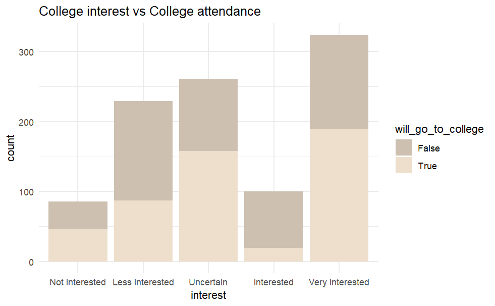

```r
df =data.frame(Dataset)
ggplot(data=df, aes(x = interest, fill = will_go_to_college)) +
  geom_bar() +
  scale_x_discrete(limits = c('Not Interested', 'Less Interested', 'Uncertain', 'Interested', 'Very Interested')) +
  labs(title = 'College interest vs College attendance ') +
  scale_fill_manual(values = c("True" = "antiquewhite2", "False" = "antiquewhite3")) +
  theme_minimal()
```

```r
NA
NA
```

Graph 2:

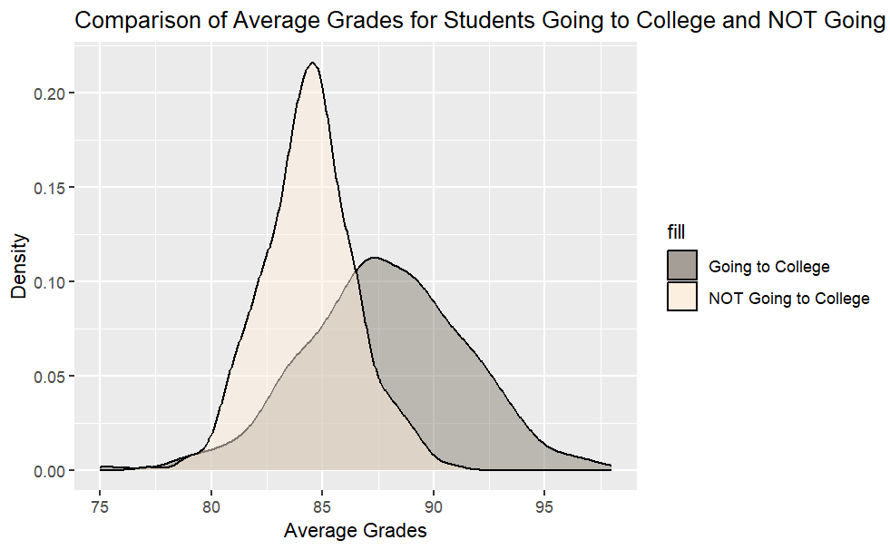

```r
filtered_True =filter(Dataset, will_go_to_college == 'True')
filtered_False =subset(Dataset, will_go_to_college =='False')

ggplot() +
  geom_density(data = filtered_True, aes(x = average_grades, fill = "Going to College"), alpha = 0.5) +
  geom_density(data = filtered_False, aes(x = average_grades, fill = "NOT Going to College"), alpha = 0.5) +
  labs(x = "Average Grades", y = "Density") +
  ggtitle("Comparison of Average Grades for Students Going to College and NOT Going to College") +
  scale_fill_manual(values = c("Going to College" = "antiquewhite4", "NOT Going to College" = "antiquewhite1"))
```

The graph shows that the average grades for students who had accepted to go to college were higher than those who did not enter college , and this indicates the existence of a correlation between those who going to college and the average grades

Graph 3:

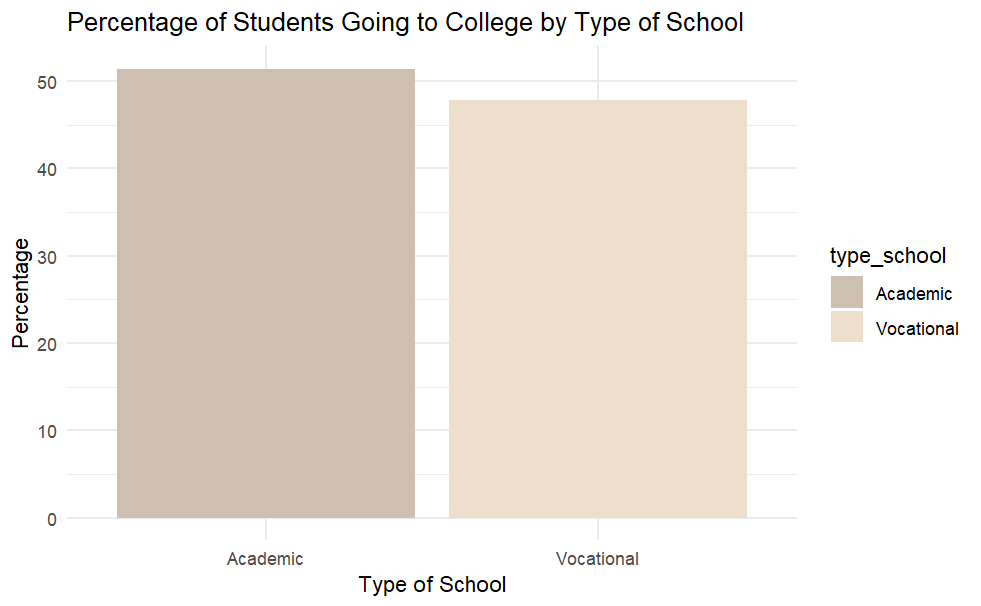

```r
Dataset_percentage <- Dataset %>%
  group_by(type_school) %>%
  summarise(percentage = mean(will_go_to_college == "True") * 100)

# Create a percentage chart
ggplot(Dataset_percentage, aes(x = type_school, y = percentage, fill = type_school)) +
  geom_bar(stat = "identity") +
  labs(title = "Percentage of Students Going to College by Type of School",
       x = "Type of School",
       y = "Percentage") +
  scale_fill_manual(values = c("Academic" = "antiquewhite3", "Vocational" = "antiquewhite2")) +
  theme_minimal()
```

```r
NA
NA
```

This graph shows the impact of the type of high school attended by students on their college attendance . Based on the bar chart:

- among students from Academic high schools, 313 are going to college, and 296 are not.
- among students from Vocational high schools, 187 are going to college, and 204 are not

Graph 4:

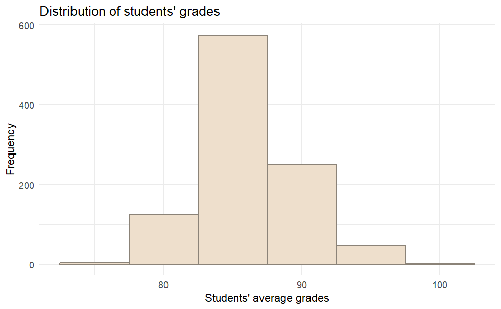

```r
ggplot(Dataset, aes(x = average_grades)) +
  geom_histogram(binwidth = 5, fill = "antiquewhite2", color = "antiquewhite4") +
  labs(title = "Distribution of students' grades",
       x = "Students' average grades",
       y = "Frequency") +
  theme_minimal()
```

This histogram show us that the majority of the students in the dataset are performing well since it seems like their grades are spanning between 75 and 98. This analysis will help us determine whether the academic performance level of students is a contributing factor to their college attendance or not.